# Reproducible research

## Loading and preprocessing the data

#### Required libraries

```r
library(dplyr)
```

#### Reading the data set

```r
data<-read.csv( "F:/Data Science/Coursera_Data_Science/5-Reproducible Research/week-2/course project/Factivity/activity.csv", sep = ",")
names(data)
```

```
## [1] "steps"    "date"     "interval"
```

#### Exloring data

```r
str(data)
```

```
## 'data.frame':    17568 obs. of  3 variables:
##  $ steps   : int  NA NA NA NA NA NA NA NA NA NA ...
##  $ date    : Factor w/ 61 levels "2012-10-01","2012-10-02",..: 1 1 1 1 1 1 1 1 1 1 ...
##  $ interval: int  0 5 10 15 20 25 30 35 40 45 ...
```

```r
head(data)
```

```
##   steps       date interval
## 1    NA 2012-10-01        0
## 2    NA 2012-10-01        5
## 3    NA 2012-10-01       10
## 4    NA 2012-10-01       15
## 5    NA 2012-10-01       20
## 6    NA 2012-10-01       25
```

```r
tail(data)
```

```
##       steps       date interval
## 17563    NA 2012-11-30     2330
## 17564    NA 2012-11-30     2335
## 17565    NA 2012-11-30     2340
## 17566    NA 2012-11-30     2345
## 17567    NA 2012-11-30     2350
## 17568    NA 2012-11-30     2355
```

## What is mean total number of steps taken per day?

#### 1-The total number of steps taken per day.

```r
data <- mutate(data, hour = interval %/% 100, minute = interval %% 100)

daily<-c()
for (i in 1:61){
  start<-(i-1)*288+1
  last<-(i-1)*288+288
  temp<-data[start:last,1]
  daily<-c(daily,sum(temp))
}
print(daily)
```

```
##  [1]    NA   126 11352 12116 13294 15420 11015    NA 12811  9900 10304
## [12] 17382 12426 15098 10139 15084 13452 10056 11829 10395  8821 13460
## [23]  8918  8355  2492  6778 10119 11458  5018  9819 15414    NA 10600
## [34] 10571    NA 10439  8334 12883  3219    NA    NA 12608 10765  7336
## [45]    NA    41  5441 14339 15110  8841  4472 12787 20427 21194 14478
## [56] 11834 11162 13646 10183  7047    NA
```

#### 2-Histogram of the total number of steps taken each day

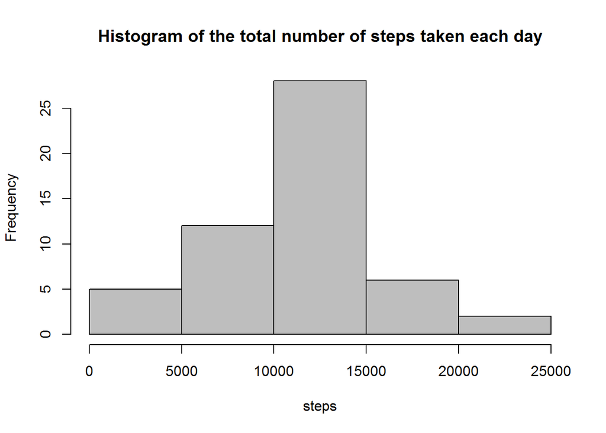

```r
daily_noNA<-daily[!is.na(daily)]
hist(daily_noNA, xlab="steps",ylab="Frequency",col="gray",
     main="Histogram of the total number of steps taken each day")
```

```r
mean<-mean(daily,na.rm=T)
median<-median(daily,na.rm=T)
```

## What is the average daily activity pattern?

#### 1-Time series plot of the average number of steps taken

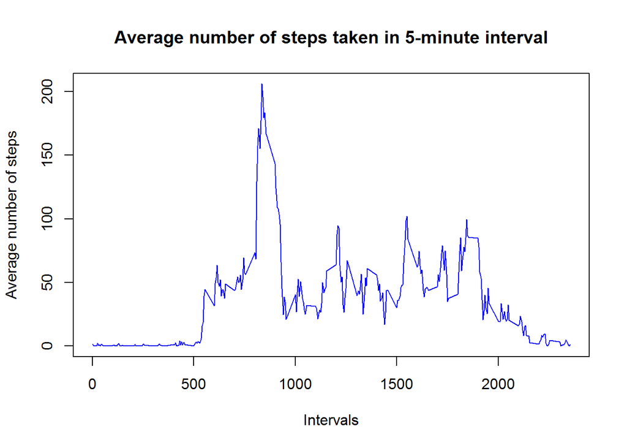

```r
x<-data[,1]
y<-matrix(x,288,61)

five_average<-apply(y,1,mean,na.rm=TRUE)

plot(data$interval[1:288],five_average, type='l',col='blue',
     xlab='Intervals',lwd=1,
     ylab='Average number of steps',
     main ='Average number of steps taken in 5-minute interval')
```

#### 2-Which 5-minute interval, on average across all the days in the dataset, contains the maximum number of steps?

```r
hour<-data$hour[1:288]
minite<-data$minute[1:288]

hour_max<-hour[which(five_average==max(five_average))]
minite_max<-minite[which(five_average==max(five_average))]

cat('The maximum number of steps occurs at',hour_max,':',minite_max,'AM')
```

```
## The maximum number of steps occurs at 8 : 35 AM
```

## Imputing missing values

#### 1-Calculate and report the total number of missing values in the dataset.

```r
sums<-sum(is.na(data[,1]))
```

The total number of missing values in the dataset is 2304.

#### 2-Devise a strategy for filling in all of the missing values in the dataset.

```r
five_average_rep<- rep(five_average,61)

data1<-data

for (i in 1:length(data1[,1])){

  if(is.na(data1[i,1])==TRUE){
    data1[i,1]= five_average_rep[i]
  }}
```

- It filled missing values using the mean of the 5-minute interval.

#### 3-Create a new dataset that is equal to the original dataset but with the missing data filled in.

- data1 is the same as the original dataset, with all missing values filled in by the mean for that 5-minute interval across all days.

- Calculate the total number of steps taken per day using the data with filled NA’s

```r
daily1<-c()

for (i in 1:61){
   start<-(i-1)*288+1
   last<-(i-1)*288+288
   temp<-data1[start:last,1]
   daily1<-c(daily1,sum(temp))
 }
```

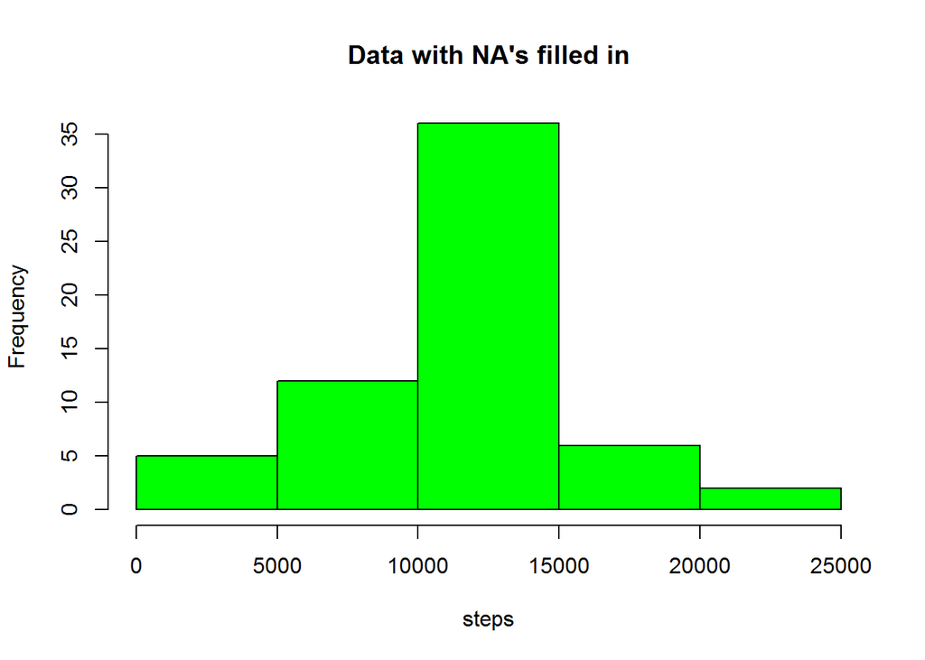

```r
hist(daily1, xlab="steps",ylab="Frequency",
     main="Data with NA's filled in",col="green")
```

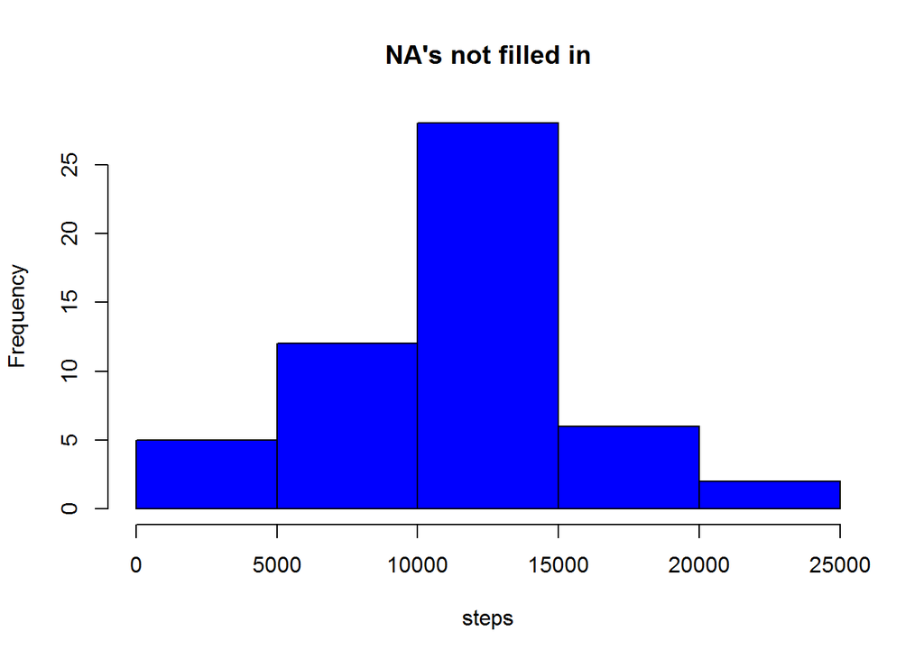

```r
hist(daily[!is.na(daily)], xlab="steps",ylab="Frequency",
     main="NA's not filled in",col="blue",)
```

```r
mean<-mean(daily1)
median<-median(daily1)
```

**Do these values differ from the estimates from the first part of the assignment? What is the impact of imputing missing data on the estimates of the total daily number of steps?**

Yes, there is a differnce in the median and in the histograms. Imputing missing data on the estimates of the total daily number of steps changes the median and the distribution. Based on the method used for filling in missing values, there is a difference in the mean and median values. The histogram can also be different based on the strategy we used to fill in the missing values.

## Are there differences in activity patterns between weekdays and weekends?

#### 1-Create a new factor variable in the dataset with two levels – “weekday” and “weekend” indicating whether a given date is a weekday or weekend day.

```r
data1$date<-as.Date(data1$date)

data1$day<-weekdays(data1$date)

data1_weekdays<-data1[(!data1$day %in% c("Saturday","Sunday")),]

data1_weekend<-data1[(data1$day %in% c("Saturday","Sunday")),]

weekday_steps<-data1_weekdays[,1]

temp<-matrix(weekday_steps,nrow=288)

weekday_steps_average<-apply(temp,1,mean)


weekend_steps<-data1_weekend[,1]

temp<-matrix(weekend_steps,nrow=288)

weekend_steps_average<-apply(temp,1,mean)
```

#### 2-Make a panel plot containing a time series plot (i.e. type = “l”) of the 5-minute interval (x-axis) and the average number of steps taken, averaged across all weekday days or weekend days (y-axis)

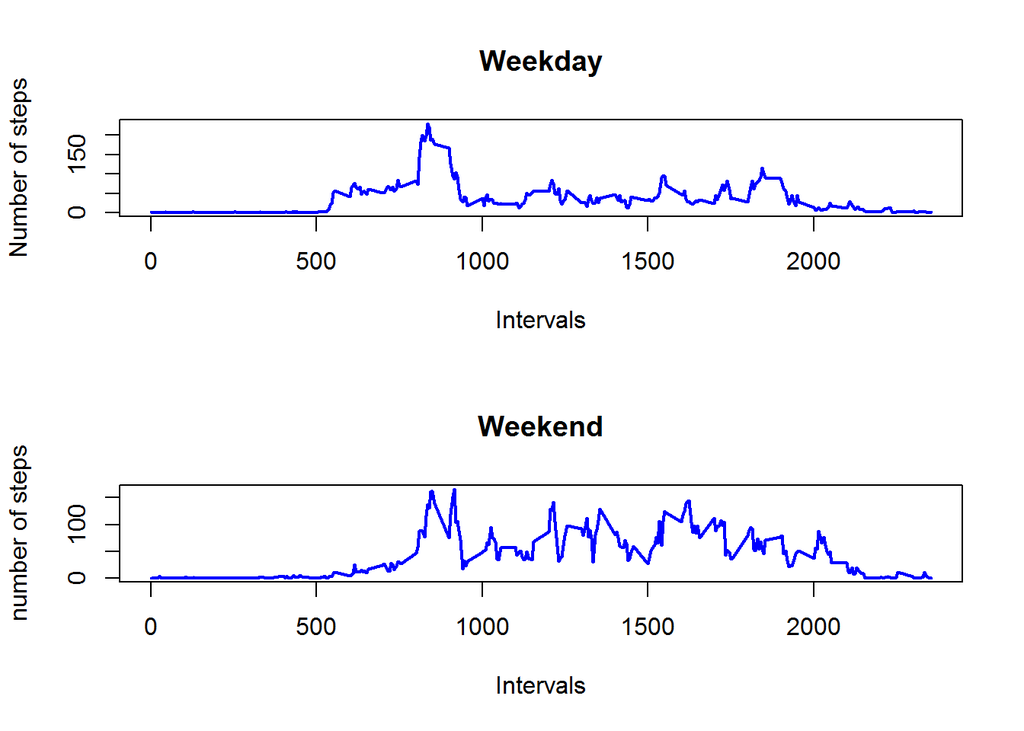

```r
par(mfrow=c(2,1))

plot(data$interval[1:288],weekday_steps_average, type="l",xlab='Intervals',ylab="Number of steps",
     col='blue',lwd=2, main="Weekday")

plot(data$interval[1:288],weekend_steps_average, type="l", xlab='Intervals',ylab="number of steps",
     col='blue',lwd=2,main="Weekend")
```